# 15. 작업 1유형 - 4

```python
import pandas as pd
df =pd.read_csv('https://raw.githubusercontent.com/Datamanim/datarepo/main/bicycle/seoul_bi.csv')
df.head()
```

|  | 대여일자 | 대여시간 | 대여소번호 | 대여구분코드 | 성별 | 연령대코드 | 이용건수 | 운동량 | 탄소량 | 이동거리 | 사용시간 |
| --- | --- | --- | --- | --- | --- | --- | --- | --- | --- | --- | --- |
| 0 | 2021-06-01 | 0 | 3541 | 정기권 | F | ~10대 | 1 | 0.00 | 0.00 | 0.00 | 8 |
| 1 | 2021-06-01 | 0 | 765 | 정기권 | F | ~10대 | 1 | 27.21 | 0.35 | 1526.81 | 19 |
| 2 | 2021-06-01 | 0 | 2637 | 정기권 | F | ~10대 | 1 | 41.40 | 0.37 | 1608.56 | 18 |
| 3 | 2021-06-01 | 0 | 2919 | 정기권 | F | ~10대 | 1 | 0.00 | 0.00 | 0.00 | 75 |
| 4 | 2021-06-01 | 0 | 549 | 정기권 | F | ~10대 | 1 | 13.04 | 0.17 | 731.55 | 6 |

## 1. 대여일자별 데이터의 수를 데이터프레임으로 출력하고, 가장 많은 데이터가 있는 날짜를 출력

```python
df['대여일자'].value_counts().sort_index().to_frame()
```

| 대여일자 | count |
| --- | --- |
| 2021-06-01 | 48081 |
| 2021-06-02 | 56100 |
| 2021-06-03 | 18985 |
| 2021-06-04 | 56788 |
| 2021-06-05 | 52730 |
| 2021-06-06 | 47787 |
| 2021-06-07 | 52623 |
| 2021-06-08 | 55623 |
| 2021-06-09 | 54507 |
| 2021-06-10 | 36992 |
| 2021-06-11 | 52089 |
| 2021-06-12 | 48569 |
| 2021-06-13 | 43131 |
| 2021-06-14 | 54945 |

```python
print(df['대여일자'].value_counts().idxmax())
```

```
2021-06-04
```

## 2. 각 일자의 요일을 표기하고 (‘Monday’ ~’Sunday’) ‘day_name’컬럼을 추가하고 이를 이용하여 각 요일별 이용 횟수의 총합을 데이터 프레임으로 출력

```python
df.info()
```

```
<class 'pandas.core.frame.DataFrame'>
RangeIndex: 678950 entries, 0 to 678949
Data columns (total 11 columns):
 #   Column  Non-Null Count   Dtype
---  ------  --------------   -----
 0   대여일자    678950 non-null  object
 1   대여시간    678950 non-null  int64
 2   대여소번호   678950 non-null  int64
 3   대여구분코드  678950 non-null  object
 4   성별      678950 non-null  object
 5   연령대코드   678950 non-null  object
 6   이용건수    678950 non-null  int64
 7   운동량     678950 non-null  object
 8   탄소량     678950 non-null  object
 9   이동거리    678950 non-null  float64
 10  사용시간    678950 non-null  int64
dtypes: float64(1), int64(4), object(6)
memory usage: 57.0+ MB
```

```python
df['대여일자'] = pd.to_datetime(df['대여일자'])
df.info()
```

```
<class 'pandas.core.frame.DataFrame'>
RangeIndex: 678950 entries, 0 to 678949
Data columns (total 11 columns):
 #   Column  Non-Null Count   Dtype
---  ------  --------------   -----
 0   대여일자    678950 non-null  datetime64[ns]
 1   대여시간    678950 non-null  int64
 2   대여소번호   678950 non-null  int64
 3   대여구분코드  678950 non-null  object
 4   성별      678950 non-null  object
 5   연령대코드   678950 non-null  object
 6   이용건수    678950 non-null  int64
 7   운동량     678950 non-null  object
 8   탄소량     678950 non-null  object
 9   이동거리    678950 non-null  float64
 10  사용시간    678950 non-null  int64
dtypes: datetime64[ns](1), float64(1), int64(4), object(5)
memory usage: 57.0+ MB
```

```python
df['day_name'] = df['대여일자'].dt.day_name()
df
```

|  | 대여일자 | 대여시간 | 대여소번호 | 대여구분코드 | 성별 | 연령대코드 | 이용건수 | 운동량 | 탄소량 | 이동거리 | 사용시간 | day_name |
| --- | --- | --- | --- | --- | --- | --- | --- | --- | --- | --- | --- | --- |
| 0 | 2021-06-01 | 0 | 3541 | 정기권 | F | ~10대 | 1 | 0.00 | 0.00 | 0.00 | 8 | Tuesday |
| 1 | 2021-06-01 | 0 | 765 | 정기권 | F | ~10대 | 1 | 27.21 | 0.35 | 1526.81 | 19 | Tuesday |
| 2 | 2021-06-01 | 0 | 2637 | 정기권 | F | ~10대 | 1 | 41.40 | 0.37 | 1608.56 | 18 | Tuesday |
| 3 | 2021-06-01 | 0 | 2919 | 정기권 | F | ~10대 | 1 | 0.00 | 0.00 | 0.00 | 75 | Tuesday |
| 4 | 2021-06-01 | 0 | 549 | 정기권 | F | ~10대 | 1 | 13.04 | 0.17 | 731.55 | 6 | Tuesday |
| ... | ... | ... | ... | ... | ... | ... | ... | ... | ... | ... | ... | ... |
| 678945 | 2021-06-14 | 23 | 4623 | 정기권 | M | 60대 | 1 | 32.92 | 0.30 | 1279.01 | 37 | Monday |
| 678946 | 2021-06-14 | 23 | 2331 | 정기권 | M | 60대 | 1 | 11.88 | 0.09 | 400.00 | 4 | Monday |
| 678947 | 2021-06-14 | 23 | 722 | 정기권 | M | 60대 | 1 | 53.28 | 0.48 | 2070.00 | 20 | Monday |
| 678948 | 2021-06-14 | 23 | 3787 | 정기권 | M | 70대~ | 1 | 121.25 | 1.18 | 5103.30 | 86 | Monday |
| 678949 | 2021-06-14 | 23 | 1911 | 정기권 | M | 70대~ | 1 | 42.18 | 0.38 | 1638.70 | 28 | Monday |

678950 rows × 12 columns

```python
df.groupby(df['day_name']).size().sort_values(ascending=False).to_frame()
```

| day_name | 0 |
| --- | --- |
| Wednesday | 110607 |
| Friday | 108877 |
| Monday | 107568 |
| Tuesday | 103704 |
| Saturday | 101299 |
| Sunday | 90918 |
| Thursday | 55977 |

## 3. 각 요일별 가장 많이 이용한 대여소의 이용횟수와 대여소 번호를 데이터 프레임으로 출력

```python
df.groupby([df['day_name'],df['대여소번호']]).size().to_frame('size').sort_values(['day_name','size']).reset_index().drop_duplicates('day_name',keep='last').set_index('day_name')
```

| day_name | 대여소번호 | size |
| --- | --- | --- |
| Friday | 502 | 277 |
| Monday | 502 | 242 |
| Saturday | 502 | 378 |
| Sunday | 502 | 372 |
| Thursday | 2715 | 137 |
| Tuesday | 502 | 267 |
| Wednesday | 502 | 282 |

## 4. 나이대별 대여구분 코드의 (일일권/전체횟수) 비율을 구한 후 가장 높은 비율을 가지는 나이대를 확인(일일권, 일일권(비회원) 모두 포함)

```python
df['일일권 여부'] = df['대여구분코드'].str.contains('일일권')
df
```

|  | 대여일자 | 대여시간 | 대여소번호 | 대여구분코드 | 성별 | 연령대코드 | 이용건수 | 운동량 | 탄소량 | 이동거리 | 사용시간 | day_name | 일일권 여부 |
| --- | --- | --- | --- | --- | --- | --- | --- | --- | --- | --- | --- | --- | --- |
| 0 | 2021-06-01 | 0 | 3541 | 정기권 | F | ~10대 | 1 | 0.00 | 0.00 | 0.00 | 8 | Tuesday | False |
| 1 | 2021-06-01 | 0 | 765 | 정기권 | F | ~10대 | 1 | 27.21 | 0.35 | 1526.81 | 19 | Tuesday | False |
| 2 | 2021-06-01 | 0 | 2637 | 정기권 | F | ~10대 | 1 | 41.40 | 0.37 | 1608.56 | 18 | Tuesday | False |
| 3 | 2021-06-01 | 0 | 2919 | 정기권 | F | ~10대 | 1 | 0.00 | 0.00 | 0.00 | 75 | Tuesday | False |
| 4 | 2021-06-01 | 0 | 549 | 정기권 | F | ~10대 | 1 | 13.04 | 0.17 | 731.55 | 6 | Tuesday | False |
| ... | ... | ... | ... | ... | ... | ... | ... | ... | ... | ... | ... | ... | ... |
| 678945 | 2021-06-14 | 23 | 4623 | 정기권 | M | 60대 | 1 | 32.92 | 0.30 | 1279.01 | 37 | Monday | False |
| 678946 | 2021-06-14 | 23 | 2331 | 정기권 | M | 60대 | 1 | 11.88 | 0.09 | 400.00 | 4 | Monday | False |
| 678947 | 2021-06-14 | 23 | 722 | 정기권 | M | 60대 | 1 | 53.28 | 0.48 | 2070.00 | 20 | Monday | False |
| 678948 | 2021-06-14 | 23 | 3787 | 정기권 | M | 70대~ | 1 | 121.25 | 1.18 | 5103.30 | 86 | Monday | False |
| 678949 | 2021-06-14 | 23 | 1911 | 정기권 | M | 70대~ | 1 | 42.18 | 0.38 | 1638.70 | 28 | Monday | False |

678950 rows × 13 columns

```python
df['일일권 여부'].groupby(df['연령대코드']).mean().to_frame()
```

| 연령대코드 | 일일권 여부 |
| --- | --- |
| 20대 | 0.239913 |
| 30대 | 0.166702 |
| 40대 | 0.110585 |
| 50대 | 0.065414 |
| 60대 | 0.042462 |
| 70대~ | 0.048962 |
| ~10대 | 0.312525 |

```python
df['일일권 여부'].groupby(df['연령대코드']).mean().idxmax()
```

```
'~10대'
```

## 5. 연령대별 평균 이동거리

```python
df['이동거리'].groupby(df['연령대코드']).mean().to_frame()
```

| 연령대코드 | 이동거리 |
| --- | --- |
| 20대 | 3211.890552 |
| 30대 | 3341.443859 |
| 40대 | 3514.857416 |
| 50대 | 3593.668100 |
| 60대 | 3538.145737 |
| 70대~ | 3085.039641 |
| ~10대 | 2634.426279 |

## 6. 연령대 코드가 20대인 데이터를 추출하고,이동거리값이 추출한 데이터의 이동거리값의 평균 이상인 데이터를 추출, 최종 추출된 데이터를 대여일자, 대여소 번호 순서로 내림차순 정렬 후 1행부터 200행까지의 탄소량의 평균을 소숫점 3째 자리

```python
df[(df['연령대코드'] == '20대')&(df['이동거리']>(df[df['연령대코드'] == '20대'].이동거리.mean()))]
```

|  | 대여일자 | 대여시간 | 대여소번호 | 대여구분코드 | 성별 | 연령대코드 | 이용건수 | 운동량 | 탄소량 | 이동거리 | 사용시간 | day_name | 일일권 여부 |
| --- | --- | --- | --- | --- | --- | --- | --- | --- | --- | --- | --- | --- | --- |
| 12 | 2021-06-01 | 0 | 302 | 정기권 | F | 20대 | 1 | 141.61 | 1.38 | 5960.00 | 28 | Tuesday | False |
| 14 | 2021-06-01 | 0 | 2173 | 정기권 | F | 20대 | 1 | 86.47 | 0.96 | 4120.00 | 31 | Tuesday | False |
| 18 | 2021-06-01 | 0 | 116 | 정기권 | F | 20대 | 1 | 196.72 | 2.30 | 9935.24 | 42 | Tuesday | False |
| 24 | 2021-06-01 | 0 | 2619 | 정기권 | F | 20대 | 1 | 112.75 | 1.14 | 4909.12 | 35 | Tuesday | False |
| 30 | 2021-06-01 | 0 | 487 | 정기권 | F | 20대 | 1 | 113.91 | 1.21 | 5230.00 | 55 | Tuesday | False |
| ... | ... | ... | ... | ... | ... | ... | ... | ... | ... | ... | ... | ... | ... |
| 678748 | 2021-06-14 | 23 | 2102 | 정기권 | M | 20대 | 1 | 267.00 | 2.70 | 11624.95 | 44 | Monday | False |
| 678749 | 2021-06-14 | 23 | 1211 | 정기권 | M | 20대 | 1 | 100.64 | 0.81 | 3481.52 | 26 | Monday | False |
| 678753 | 2021-06-14 | 23 | 2034 | 정기권 | M | 20대 | 1 | 514.35 | 3.59 | 15462.66 | 49 | Monday | False |
| 678756 | 2021-06-14 | 23 | 502 | 정기권 | M | 20대 | 1 | 264.03 | 2.09 | 9010.00 | 43 | Monday | False |
| 678757 | 2021-06-14 | 23 | 722 | 정기권 | M | 20대 | 1 | 512.64 | 4.62 | 19916.21 | 97 | Monday | False |

73671 rows × 13 columns

```python
df[(df['연령대코드'] == '20대')&(df['이동거리']>(df[df['연령대코드'] == '20대'].이동거리.mean()))].sort_values(['대여일자','대여소번호'],ascending=False).head(200).탄소량.astype('float').mean().round(3)
```

```
1.613
```

## 7. 6월 7일 ~10대의 “이용건수”의 중앙값

```python
df[(df['대여일자'] == pd.to_datetime('2021-06-07')) & (df['연령대코드'] == '~10대')].이용건수.median()
```

```
1.0
```

## 8. 평일 (월~금) 출근 시간대(오전 6,7,8시)의 대여소별 이용 횟수를 구해서 데이터 프레임 형태로 표현한 후 각 대여시간별 이용 횟수의 상위 3개 대여소와 이용횟수를 출력

```python
df2 = df[(df['day_name'].apply(lambda x: x not in ['Saturday','Sunday'])) & (df['대여시간'].apply(lambda x: x in [6,7,8]))]
df2.groupby([df['대여시간'],df['대여소번호']]).size().to_frame('이용횟수').sort_values(['대여시간','이용횟수'],ascending=[True,False]).groupby('대여시간').head(3)
```

| 대여시간 | 대여소번호 | 이용횟수 |
| --- | --- | --- |
| 6 | 2744 | 45 |
|  | 1125 | 40 |
|  | 1028 | 36 |
| 7 | 259 | 104 |
|  | 230 | 77 |
|  | 726 | 77 |
| 8 | 2701 | 119 |
|  | 646 | 115 |
|  | 1152 | 92 |

## 9. 이동거리의 평균 이상의 이동거리 값을 가지는 데이터를 추출하여 추출데이터의 이동거리의 표본표준편차 값

```python
df[df['이동거리']>(df['이동거리'].mean())].이동거리.std()
```

```
5092.139707505305
```

## 10. 남성(‘M’ or ‘m’)과 여성(‘F’ or ‘f’)의 이동거리값의 평균값

```python
df['성별'] = df['성별'].str.upper()
df.groupby('성별',as_index=False).이동거리.mean()
```

|  | 성별 | 이동거리 |
| --- | --- | --- |
| 0 | F | 3468.575025 |
| 1 | M | 3209.110871 |

## 번외: 분석 및 시각화

```python
df.info()
```

```
<class 'pandas.core.frame.DataFrame'>
RangeIndex: 678950 entries, 0 to 678949
Data columns (total 13 columns):
 #   Column    Non-Null Count   Dtype
---  ------    --------------   -----
 0   대여일자      678950 non-null  datetime64[ns]
 1   대여시간      678950 non-null  int64
 2   대여소번호     678950 non-null  int64
 3   대여구분코드    678950 non-null  object
 4   성별        678950 non-null  object
 5   연령대코드     678950 non-null  object
 6   이용건수      678950 non-null  int64
 7   운동량       678950 non-null  object
 8   탄소량       678950 non-null  object
 9   이동거리      678950 non-null  float64
 10  사용시간      678950 non-null  int64
 11  day_name  678950 non-null  object
 12  일일권 여부    678950 non-null  bool
dtypes: bool(1), datetime64[ns](1), float64(1), int64(4), object(6)
memory usage: 62.8+ MB
```

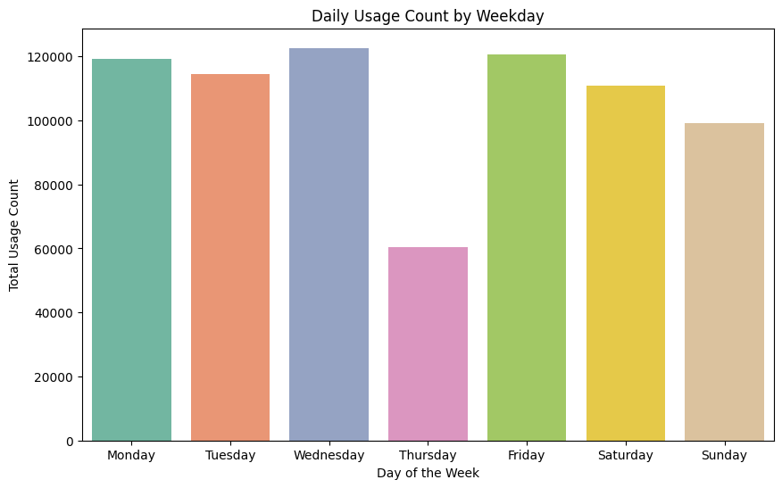

```python
import pandas as pd
import matplotlib.pyplot as plt
import seaborn as sns

daily_usage = df.groupby('day_name')['이용건수'].sum()

days_order = ['Monday', 'Tuesday', 'Wednesday', 'Thursday', 'Friday', 'Saturday', 'Sunday']
daily_usage = daily_usage[days_order]

plt.figure(figsize=(10, 6))
sns.barplot(x=daily_usage.index, y=daily_usage.values, hue=daily_usage.index, palette='Set2')
plt.title('Daily Usage Count by Weekday')
plt.xlabel('Day of the Week')
plt.ylabel('Total Usage Count')
plt.show()
```

### 목요일만 이용건수가 특히 낮은 현상이 관측됨: 데이터가 오염되었을 가능성

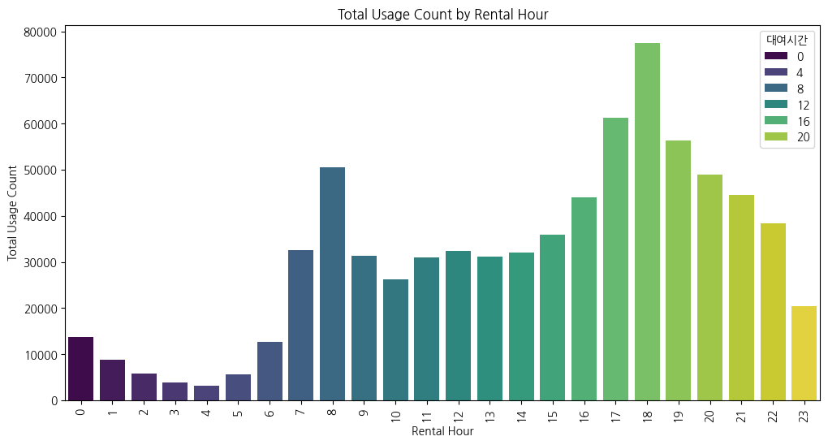

```python
hourly_usage = df.groupby('대여시간')['이용건수'].sum()

plt.rcParams['font.family'] = 'NanumGothic'
plt.figure(figsize=(12, 6))
sns.barplot(x=hourly_usage.index, y=hourly_usage.values, hue=hourly_usage.index, palette='viridis')
plt.title('Total Usage Count by Rental Hour')
plt.xlabel('Rental Hour')
plt.ylabel('Total Usage Count')
plt.xticks(rotation=90)
plt.show()
```

### 결론: 출퇴근 시간에 특히 이용건수가 많다.